# Lecture 12 - Last data viusualization

Ben Rogers

2022-10-18

# More Data Visualization

## Zooming

To zoom in on a region of the plot, it’s generally best to use coord_cartesian(). Compare the following two plots.

```r
ggplot(mpg, mapping = aes(displ, hwy)) +
  geom_point(aes(color = class)) +
  geom_smooth() +
  coord_cartesian(xlim = c(5, 7), ylim = c(10, 30))
```

```r
ggplot(mpg, mapping = aes(displ, hwy)) +
  geom_point(aes(color = class)) +
  geom_smooth() +
  scale_x_continuous(limits=c(5,7))+
  scale_y_continuous(limits=c(10,30))
```

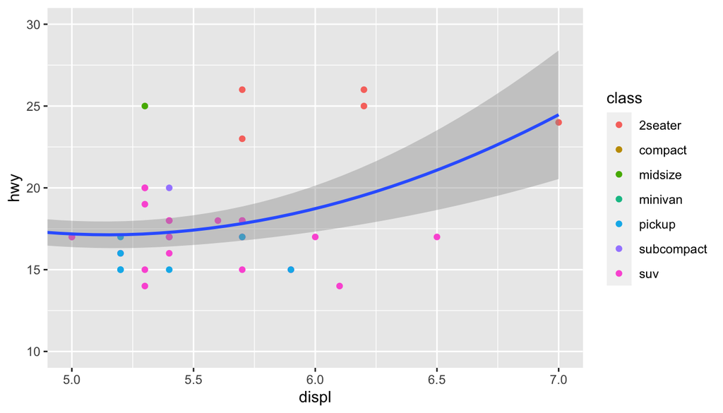

```r
ggplot(mpg, mapping = aes(displ, hwy)) +
  geom_point(aes(color = class)) +
  geom_smooth() +
  coord_cartesian(xlim = c(5, 7), ylim = c(10, 30))
```

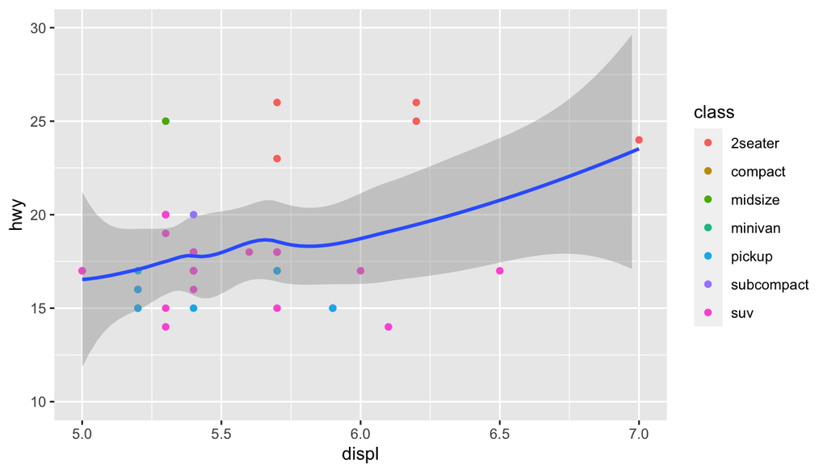

```r
ggplot(mpg, mapping = aes(displ, hwy)) +
  geom_point(aes(color = class)) +
  geom_smooth() +
  scale_x_continuous(limits=c(5,7))+
  scale_y_continuous(limits=c(10,30))
```

## Themes

You can customise the non-data elements of your plot with a theme.

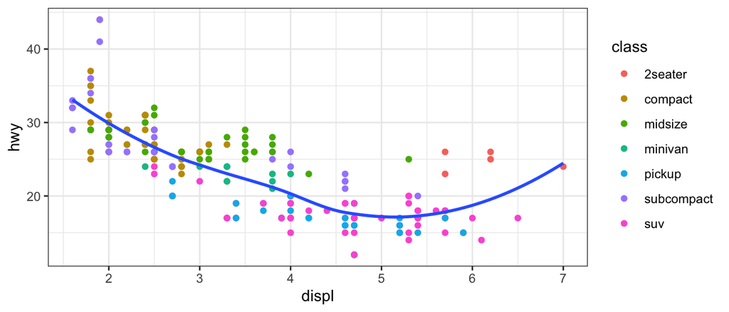

```r
ggplot(mpg, aes(displ, hwy)) +
  geom_point(aes(color = class)) +
  geom_smooth(se = FALSE) +
  theme_bw()
```

## Themes

## Saving your plots

There are two main ways to get your plots out of R and into your final write-up: ggsave() and knitr. ggsave() will save the most recent plot to disk:

```r
ggplot(mpg, aes(displ, hwy)) + geom_point()
ggsave("my-plot.pdf")
```

If you don’t specify the width and height they will be taken from the dimensions of the current plotting device. For reproducible code, you’ll want to specify them.

## Summary

How ggplot2 builds a graph

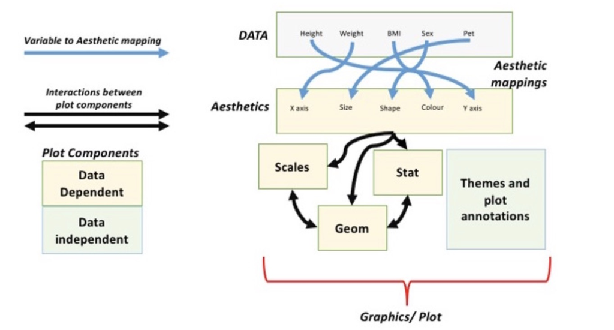

## The Layered Grammar of Graphics

```r
ggplot(data = <DATA>) +
  <GEOM_FUNCTION>(
     mapping = aes(<MAPPINGS>),
     stat = <STAT>,
     position = <POSITION>
  ) +
  <COORDINATE_FUNCTION> +
  <FACET_FUNCTION>
```

## Learning More

Book `ggplot2: Elegant graphics for data analysis` goes into much more depth about the underlying theory, has many more examples of how to compine the individual pieces to solve practical problems.

You can find the source code at https://github.com/hadley/ggplot2-book

Another great resource is the ggplot2 extensions gallery https://exts.ggplot2.tidyverse.org/gallery/. This site lists many of the packages that extend ggplot2 with new geoms and scales.